# Project 1 - Phase 2

Tomasz K, Marcel Sz

2015-10-14

# Introduction

The solution presents performance of few different classifiers:

- K-nearest neighbors
- SVM
- Decision Tree
- Random Forest
- Naive Bayes

Classifiers are evaluated using:

- Accuracy and Kappa using confusion Matrix
- K-fold cross validation
- Bootstrap
- ROC Curves
- Area Under Curve

# Preparing data

The ‘australian’ dataset comprising credit card data is loaded from: http://archive.ics.uci.edu/ml/machine-learning-databases/statlog/australian/australian.dat

The dataset is split into training and testing set (with 75-25 ratio).

```r
library(caret)
library(ROCR)
library(randomForest)
library(e1071)
library(party)
library(rpart)
library(Hmisc)


australian = read.table("http://archive.ics.uci.edu/ml/machine-learning-databases/statlog/australian/australian.dat",
        sep=" ",header=F,fill=FALSE,strip.white=T)

originalaustralian <-australian
australian$V15 <- factor(australian$V15)

# Training/Testing set partition
indxTrain <- createDataPartition(y = australian$V15, p = 0.75)
australianTrain<- australian[indxTrain$Resample1,]
australianTest <- australian[-indxTrain$Resample1,]
australianTrain$V15 <- factor(australianTrain$V15)
```

# Random Forest

```r
fullForest <- randomForest(V15 ~ ., data = australian, importance = TRUE, na.action = na.omit)
```

We will use random forest to extract, say 5, most important features.

```r
importance(fullForest)
```

```
##             0         1 MeanDecreaseAccuracy MeanDecreaseGini
## V1  -1.718915 -1.518538           -2.2006591         3.543331
## V2   3.789693  2.428262            4.3743716        23.051456
## V3   2.954838  9.352425            8.9852856        26.501473
## V4   4.577004  4.355778            6.0573098         6.005473
## V5  12.203918 14.034139           17.6230002        25.181749
## V6   4.068838  3.774160            5.8450935         8.990188
## V7   9.648208 12.824556           15.5498275        32.432703
## V8  54.859490 51.412478           62.7937364        96.251785
## V9   8.668149 13.251031           15.1530086        19.892899
## V10 12.336753 13.226136           16.7130267        33.924501
## V11  2.244758 -3.494555           -0.7057478         3.926101
## V12 -2.976941  7.696648            3.7420363         4.147045
## V13  7.431360  8.059705           10.9634341        22.709220
## V14 12.840587 11.699308           17.2714952        27.345178
```

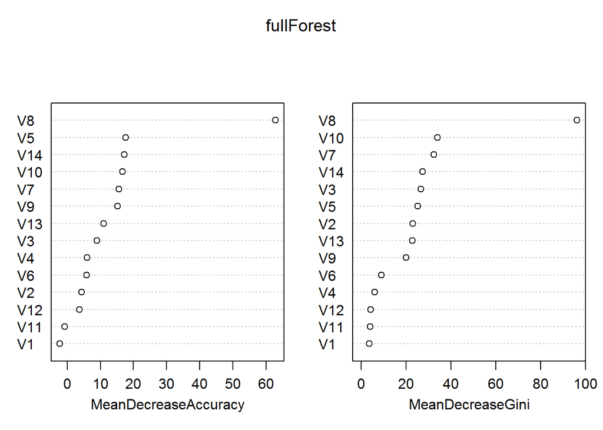

```r
varImpPlot(fullForest)
```

# K - Nearest Neighbors

## Data Normalization

Because K-nn classifier uses distance calculation to determine nearest neighbors we have to normalize feature values.

```r
australianNormalized <- australian
australianNormalized$V15 <- factor(australianNormalized$V15)
australianNormalized$V1 <- scale(australianNormalized$V1)
australianNormalized$V2 <- scale(australianNormalized$V2)
australianNormalized$V3 <- scale(australianNormalized$V3)
australianNormalized$V4 <- scale(australianNormalized$V4)
australianNormalized$V5 <- scale(australianNormalized$V5)
australianNormalized$V6 <- scale(australianNormalized$V6)
australianNormalized$V7 <- scale(australianNormalized$V7)
australianNormalized$V8 <- scale(australianNormalized$V8)
australianNormalized$V9 <- scale(australianNormalized$V9)
australianNormalized$V10 <- scale(australianNormalized$V10)
australianNormalized$V11 <- scale(australianNormalized$V11)
australianNormalized$V12 <- scale(australianNormalized$V12)
australianNormalized$V13 <- scale(australianNormalized$V13)
australianNormalized$V14 <- scale(australianNormalized$V14)

# Training/Testing set partition
indxTrain <- createDataPartition(y = australianNormalized$V15, p = 0.75)
australianNormalizedTrain<- australianNormalized[indxTrain$Resample1,]
australianNormalizedTest <- australianNormalized[-indxTrain$Resample1,]
```

## K-fold Cross Validation

To obtain best accuracy we must try several values of k, say 40, and find best one.

```r
train_control <- trainControl(method="cv", number=10)
model <- train(V15 ~ V8 + V14 + V5 + V10 + V7, data=australianNormalizedTrain, trControl=train_control, method="knn", tuneLength = 40)
predTab <- predict(model, australianNormalizedTest)
confusion_matrix <- confusionMatrix(predTab, australianNormalizedTest$V15)
confusion_matrix
```

```
## Confusion Matrix and Statistics
##
##           Reference
## Prediction  0  1
##          0 80 13
##          1 15 63
##
##                Accuracy : 0.8363
##                  95% CI : (0.7721, 0.8884)
##     No Information Rate : 0.5556
##     P-Value [Acc > NIR] : 5.994e-15
##
##                   Kappa : 0.6693
##  Mcnemar's Test P-Value : 0.8501
##
##             Sensitivity : 0.8421
##             Specificity : 0.8289
##          Pos Pred Value : 0.8602
##          Neg Pred Value : 0.8077
##              Prevalence : 0.5556
##          Detection Rate : 0.4678
##    Detection Prevalence : 0.5439
##       Balanced Accuracy : 0.8355
##
##        'Positive' Class : 0
##
```

```r
cvk = model$bestTune[[1]]
```

## Bootstrap

```r
train_control <- trainControl(method="boot", number=10)
model <- train(V15 ~ V8 + V14 + V5 + V10 + V7, data=australianNormalizedTrain, trControl=train_control, method="knn", tuneLength = 40)
predTab <- predict(model, australianNormalizedTest)
confusion_matrix <- confusionMatrix(predTab, australianNormalizedTest$V15)
confusion_matrix
```

```
## Confusion Matrix and Statistics
##
##           Reference
## Prediction  0  1
##          0 81 13
##          1 14 63
##
##                Accuracy : 0.8421
##                  95% CI : (0.7786, 0.8933)
##     No Information Rate : 0.5556
##     P-Value [Acc > NIR] : 1.438e-15
##
##                   Kappa : 0.6807
##  Mcnemar's Test P-Value : 1
##
##             Sensitivity : 0.8526
##             Specificity : 0.8289
##          Pos Pred Value : 0.8617
##          Neg Pred Value : 0.8182
##              Prevalence : 0.5556
##          Detection Rate : 0.4737
##    Detection Prevalence : 0.5497
##       Balanced Accuracy : 0.8408
##
##        'Positive' Class : 0
##
```

```r
bk = model$bestTune[[1]]
```

# SVM

## Training and testing sets

```r
svm1 <- svm(V15 ~ V8 + V14 + V5 + V10 + V7, data = australianTrain, kernel='linear', cost=10, scale=FALSE, probability = TRUE)
predictions <- predict(svm1, australianTest)
confusion_matrix <- confusionMatrix(predictions, australianTest$V15)
confusion_matrix
```

```
## Confusion Matrix and Statistics
##
##           Reference
## Prediction  0  1
##          0 86 33
##          1  9 43
##
##                Accuracy : 0.7544
##                  95% CI : (0.6828, 0.8169)
##     No Information Rate : 0.5556
##     P-Value [Acc > NIR] : 5.577e-08
##
##                   Kappa : 0.4864
##  Mcnemar's Test P-Value : 0.0003867
##
##             Sensitivity : 0.9053
##             Specificity : 0.5658
##          Pos Pred Value : 0.7227
##          Neg Pred Value : 0.8269
##              Prevalence : 0.5556
##          Detection Rate : 0.5029
##    Detection Prevalence : 0.6959
##       Balanced Accuracy : 0.7355
##
##        'Positive' Class : 0
##
```

## K-fold cross validation

```r
train_control <- trainControl(method="cv", number=10)
svm2 <- train(V15 ~ V8 + V14 + V5 + V10 + V7, data=australian, trControl=train_control, method="svmLinear")
predictions <- predict(svm2, australian)
confusion_matrix <- confusionMatrix(predictions, australian$V15)
confusion_matrix
```

```
## Confusion Matrix and Statistics
##
##           Reference
## Prediction   0   1
##          0 306  22
##          1  77 285
##
##                Accuracy : 0.8565
##                  95% CI : (0.8281, 0.8818)
##     No Information Rate : 0.5551
##     P-Value [Acc > NIR] : < 2.2e-16
##
##                   Kappa : 0.7146
##  Mcnemar's Test P-Value : 5.724e-08
##
##             Sensitivity : 0.7990
##             Specificity : 0.9283
##          Pos Pred Value : 0.9329
##          Neg Pred Value : 0.7873
##              Prevalence : 0.5551
##          Detection Rate : 0.4435
##    Detection Prevalence : 0.4754
##       Balanced Accuracy : 0.8636
##
##        'Positive' Class : 0
##
```

## Bootstrap

```r
train_control <- trainControl(method="boot", number=10)
svm3 <- train(V15 ~ V8 + V14 + V5 + V10 + V7, data=australian, trControl=train_control, method="svmLinear")
predictions <- predict(svm3, australian)
confusion_matrix <- confusionMatrix(predictions, australian$V15)
confusion_matrix
```

```
## Confusion Matrix and Statistics
##
##           Reference
## Prediction   0   1
##          0 306  22
##          1  77 285
##
##                Accuracy : 0.8565
##                  95% CI : (0.8281, 0.8818)
##     No Information Rate : 0.5551
##     P-Value [Acc > NIR] : < 2.2e-16
##
##                   Kappa : 0.7146
##  Mcnemar's Test P-Value : 5.724e-08
##
##             Sensitivity : 0.7990
##             Specificity : 0.9283
##          Pos Pred Value : 0.9329
##          Neg Pred Value : 0.7873
##              Prevalence : 0.5551
##          Detection Rate : 0.4435
##    Detection Prevalence : 0.4754
##       Balanced Accuracy : 0.8636
##
##        'Positive' Class : 0
##
```

# Random forest

## Training and testing sets

```r
forest1 <- randomForest(V15 ~ V8 + V14 + V5 + V10 + V7, data = australianTrain, importance = TRUE, na.action = na.omit)
predictions <- predict(forest1, australianTest)
confusion_matrix <- confusionMatrix(predictions, australianTest$V15)
confusion_matrix
```

```
## Confusion Matrix and Statistics
##
##           Reference
## Prediction  0  1
##          0 79 11
##          1 16 65
##
##                Accuracy : 0.8421
##                  95% CI : (0.7786, 0.8933)
##     No Information Rate : 0.5556
##     P-Value [Acc > NIR] : 1.438e-15
##
##                   Kappa : 0.6824
##  Mcnemar's Test P-Value : 0.4414
##
##             Sensitivity : 0.8316
##             Specificity : 0.8553
##          Pos Pred Value : 0.8778
##          Neg Pred Value : 0.8025
##              Prevalence : 0.5556
##          Detection Rate : 0.4620
##    Detection Prevalence : 0.5263
##       Balanced Accuracy : 0.8434
##
##        'Positive' Class : 0
##
```

## K-fold cross validation

```r
train_control <- trainControl(method="cv", number=10)
forest2 <- train(V15 ~ V8 + V14 + V5 + V10 + V7, data=australian, trControl=train_control, method="rf")
predictions <- predict(forest2, australian)
confusion_matrix <- confusionMatrix(predictions, australian$V15)
confusion_matrix
```

```
## Confusion Matrix and Statistics
##
##           Reference
## Prediction   0   1
##          0 374  21
##          1   9 286
##
##                Accuracy : 0.9565
##                  95% CI : (0.9385, 0.9705)
##     No Information Rate : 0.5551
##     P-Value [Acc > NIR] : < 2e-16
##
##                   Kappa : 0.9116
##  Mcnemar's Test P-Value : 0.04461
##
##             Sensitivity : 0.9765
##             Specificity : 0.9316
##          Pos Pred Value : 0.9468
##          Neg Pred Value : 0.9695
##              Prevalence : 0.5551
##          Detection Rate : 0.5420
##    Detection Prevalence : 0.5725
##       Balanced Accuracy : 0.9540
##
##        'Positive' Class : 0
##
```

## Bootstrap

```r
train_control <- trainControl(method="boot", number=10)
forest3 <- train(V15 ~ V8 + V14 + V5 + V10 + V7, data=australian, trControl=train_control, method="rf")
predictions <- predict(forest3, australian)
confusion_matrix <- confusionMatrix(predictions, australian$V15)
confusion_matrix
```

```
## Confusion Matrix and Statistics
##
##           Reference
## Prediction   0   1
##          0 377  22
##          1   6 285
##
##                Accuracy : 0.9594
##                  95% CI : (0.9419, 0.9729)
##     No Information Rate : 0.5551
##     P-Value [Acc > NIR] : < 2.2e-16
##
##                   Kappa : 0.9174
##  Mcnemar's Test P-Value : 0.004586
##
##             Sensitivity : 0.9843
##             Specificity : 0.9283
##          Pos Pred Value : 0.9449
##          Neg Pred Value : 0.9794
##              Prevalence : 0.5551
##          Detection Rate : 0.5464
##    Detection Prevalence : 0.5783
##       Balanced Accuracy : 0.9563
##
##        'Positive' Class : 0
##
```

# Decision Tree

## Training and testing sets

```r
# ctree
ctree1 <- ctree(V15 ~ V8 + V14 + V5 + V10 + V7, data=australianTrain)
predictions <- predict(ctree1, australianTest)
confusion_matrix <- confusionMatrix(predictions, australianTest$V15)
confusion_matrix
```

```
## Confusion Matrix and Statistics
##
##           Reference
## Prediction  0  1
##          0 78 12
##          1 17 64
##
##                Accuracy : 0.8304
##                  95% CI : (0.7656, 0.8834)
##     No Information Rate : 0.5556
##     P-Value [Acc > NIR] : 2.397e-14
##
##                   Kappa : 0.6588
##  Mcnemar's Test P-Value : 0.4576
##
##             Sensitivity : 0.8211
##             Specificity : 0.8421
##          Pos Pred Value : 0.8667
##          Neg Pred Value : 0.7901
##              Prevalence : 0.5556
##          Detection Rate : 0.4561
##    Detection Prevalence : 0.5263
##       Balanced Accuracy : 0.8316
##
##        'Positive' Class : 0
##
```

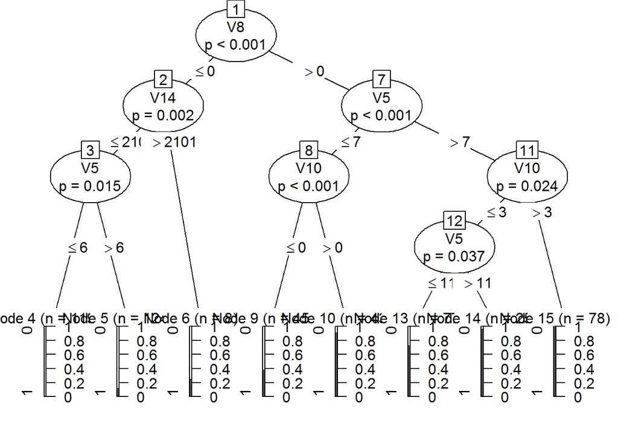

```r
plot(ctree1)
```

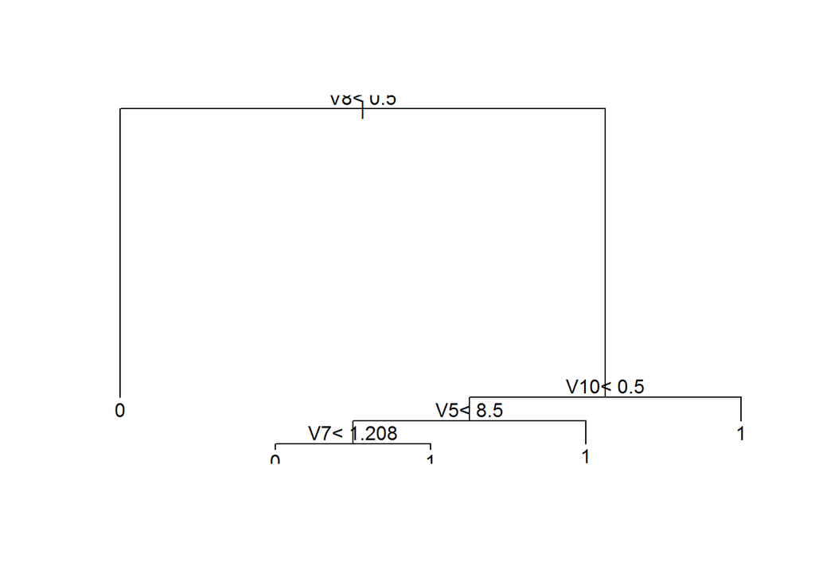

```r
# rtree
rtree1 <- rpart(V15 ~ V8 + V14 + V5 + V10 + V7, data=australianTrain, method="class")
predictions <- predict(rtree1, australianTest)
plot(rtree1)
text(rtree1)
```

## K-fold cross validation

```r
train_control <- trainControl(method="cv", number=10)

# ctree
ctree2 <- train(V15 ~ V8 + V14 + V5 + V10 + V7, data=australian, trControl=train_control, method="ctree")
predictions <- predict(ctree2, australian)
confusion_matrix <- confusionMatrix(predictions, australian$V15)
confusion_matrix
```

```
## Confusion Matrix and Statistics
##
##           Reference
## Prediction   0   1
##          0 357  59
##          1  26 248
##
##                Accuracy : 0.8768
##                  95% CI : (0.8499, 0.9004)
##     No Information Rate : 0.5551
##     P-Value [Acc > NIR] : < 2.2e-16
##
##                   Kappa : 0.7479
##  Mcnemar's Test P-Value : 0.0005187
##
##             Sensitivity : 0.9321
##             Specificity : 0.8078
##          Pos Pred Value : 0.8582
##          Neg Pred Value : 0.9051
##              Prevalence : 0.5551
##          Detection Rate : 0.5174
##    Detection Prevalence : 0.6029
##       Balanced Accuracy : 0.8700
##
##        'Positive' Class : 0
##
```

```r
# rtree
rtree2 <- train(V15 ~ V8 + V14 + V5 + V10 + V7, data=australian, trControl=train_control, method="rpart")
predictions <- predict(rtree2, australian)
confusion_matrix <- confusionMatrix(predictions, australian$V15)
confusion_matrix
```

```
## Confusion Matrix and Statistics
##
##           Reference
## Prediction   0   1
##          0 339  41
##          1  44 266
##
##                Accuracy : 0.8768
##                  95% CI : (0.8499, 0.9004)
##     No Information Rate : 0.5551
##     P-Value [Acc > NIR] : <2e-16
##
##                   Kappa : 0.7508
##  Mcnemar's Test P-Value : 0.8283
##
##             Sensitivity : 0.8851
##             Specificity : 0.8664
##          Pos Pred Value : 0.8921
##          Neg Pred Value : 0.8581
##              Prevalence : 0.5551
##          Detection Rate : 0.4913
##    Detection Prevalence : 0.5507
##       Balanced Accuracy : 0.8758
##
##        'Positive' Class : 0
##
```

## Bootstrap

```r
train_control <- trainControl(method="boot", number=10)

# ctree
ctree2 <- train(V15 ~ V8 + V14 + V5 + V10 + V7, data=australian, trControl=train_control, method="ctree")
predictions <- predict(ctree2, australian)
confusion_matrix <- confusionMatrix(predictions, australian$V15)
confusion_matrix
```

```
## Confusion Matrix and Statistics
##
##           Reference
## Prediction   0   1
##          0 341  56
##          1  42 251
##
##                Accuracy : 0.858
##                  95% CI : (0.8297, 0.8832)
##     No Information Rate : 0.5551
##     P-Value [Acc > NIR] : <2e-16
##
##                   Kappa : 0.7111
##  Mcnemar's Test P-Value : 0.1891
##
##             Sensitivity : 0.8903
##             Specificity : 0.8176
##          Pos Pred Value : 0.8589
##          Neg Pred Value : 0.8567
##              Prevalence : 0.5551
##          Detection Rate : 0.4942
##    Detection Prevalence : 0.5754
##       Balanced Accuracy : 0.8540
##
##        'Positive' Class : 0
##
```

```r
# rtree
rtree2 <- train(V15 ~ V8 + V14 + V5 + V10 + V7, data=australian, trControl=train_control, method="rpart")
predictions <- predict(rtree2, australian)
confusion_matrix <- confusionMatrix(predictions, australian$V15)
confusion_matrix
```

```
## Confusion Matrix and Statistics
##
##           Reference
## Prediction   0   1
##          0 306  23
##          1  77 284
##
##                Accuracy : 0.8551
##                  95% CI : (0.8266, 0.8805)
##     No Information Rate : 0.5551
##     P-Value [Acc > NIR] : < 2.2e-16
##
##                   Kappa : 0.7116
##  Mcnemar's Test P-Value : 1.158e-07
##
##             Sensitivity : 0.7990
##             Specificity : 0.9251
##          Pos Pred Value : 0.9301
##          Neg Pred Value : 0.7867
##              Prevalence : 0.5551
##          Detection Rate : 0.4435
##    Detection Prevalence : 0.4768
##       Balanced Accuracy : 0.8620
##
##        'Positive' Class : 0
##
```

# Naive Bayes

## Data Preparation

For naive bayes classifier it is good to split the feature values into ranges of equal size (with regard to number of observations).

Spliting is achieved using cut2 function, factor will be used when the value either one or zero.

```r
aust_equal_size <- originalaustralian
for (i in c(2, 3, 4, 5, 6, 7, 10, 12, 13, 14)) {
  aust_equal_size[,i]<- cut2(australian[,i], g=3)
}
aust_equal_size$V15 <- factor(ifelse(aust_equal_size$V15 == 0, "Yes", "No"))
aust_equal_size$V1 <-factor(aust_equal_size$V1)
aust_equal_size$V8 <-factor(aust_equal_size$V8)
aust_equal_size$V9 <-factor(aust_equal_size$V9)
aust_equal_size$V11 <-factor(aust_equal_size$V11)
summary(aust_equal_size)
```

```
##  V1                V2                 V3          V4            V5
##  0:222   [13.8,24.2):230   [0.00, 1.54):239   [1,3):688   [ 1, 7):257
##  1:468   [24.2,34.2):231   [1.54, 5.08):221   3    :  2   [ 7,10):248
##          [34.2,80.2]:229   [5.08,28.00]:230               [10,14]:185
##      V6                   V7      V8      V9          V10      V11
##  [1,5):479   [0.000, 0.335):234   0:329   0:395   0     :395   0:374
##  [5,9]:211   [0.335, 2.040):238   1:361   1:295   1     : 71   1:316
##              [2.040,28.500]:218                   [2,67]:224
##     V12              V13                V14       V15
##  [1,3):682   [  0, 102):242     1         :295   No :307
##  3    :  8   [102, 220):219   [  2,   159):165   Yes:383
##              [220,2000]:229   [159,100001]:230
```

```r
# Training/Testing set partition
indxTrain <- createDataPartition(y = aust_equal_size$V15, p = 0.8)
aust_equal_sizeTrain<- aust_equal_size[indxTrain$Resample1,]
aust_equal_sizeTest <- aust_equal_size[-indxTrain$Resample1,]
```

## K-fold cross validation

```r
train_control <- trainControl(method="cv", number=10)
nb_k_model <- train(V15 ~ V8 + V14 + V5 + V10 + V7, data=aust_equal_sizeTrain, trControl=train_control, method="nb")
nb_k_predTab <- predict(nb_k_model, aust_equal_sizeTest)
confusion_matrix <- confusionMatrix(nb_k_predTab, aust_equal_sizeTest$V15)
confusion_matrix
```

```
## Confusion Matrix and Statistics
##
##           Reference
## Prediction No Yes
##        No  50  10
##        Yes 11  66
##
##                Accuracy : 0.8467
##                  95% CI : (0.7753, 0.9025)
##     No Information Rate : 0.5547
##     P-Value [Acc > NIR] : 3.197e-13
##
##                   Kappa : 0.6892
##  Mcnemar's Test P-Value : 1
##
##             Sensitivity : 0.8197
##             Specificity : 0.8684
##          Pos Pred Value : 0.8333
##          Neg Pred Value : 0.8571
##              Prevalence : 0.4453
##          Detection Rate : 0.3650
##    Detection Prevalence : 0.4380
##       Balanced Accuracy : 0.8440
##
##        'Positive' Class : No
##
```

## Bootstraps

```r
train_control <- trainControl(method="boot", number=10)
nb_b_model <- train(V15 ~ V8 + V14 + V5 + V10 + V7, data=aust_equal_sizeTrain, trControl=train_control, method="nb")
nb_b_predTab <- predict(nb_b_model, aust_equal_sizeTest)
confusion_matrix <- confusionMatrix(nb_b_predTab, aust_equal_sizeTest$V15)
confusion_matrix
```

```
## Confusion Matrix and Statistics
##
##           Reference
## Prediction No Yes
##        No  50  10
##        Yes 11  66
##
##                Accuracy : 0.8467
##                  95% CI : (0.7753, 0.9025)
##     No Information Rate : 0.5547
##     P-Value [Acc > NIR] : 3.197e-13
##
##                   Kappa : 0.6892
##  Mcnemar's Test P-Value : 1
##
##             Sensitivity : 0.8197
##             Specificity : 0.8684
##          Pos Pred Value : 0.8333
##          Neg Pred Value : 0.8571
##              Prevalence : 0.4453
##          Detection Rate : 0.3650
##    Detection Prevalence : 0.4380
##       Balanced Accuracy : 0.8440
##
##        'Positive' Class : No
##
```